# Práctica 2

Lorena Romero y María Soto

2023-11-22

```r
library(ggplot2)
library(tidyverse)
library(gridExtra)
library(reshape2)
library(GGally)
library(ggfortify)
library(caret)
library(dplyr)
library(FactoMineR)
library(factoextra)
library(plotly)
```

Sys.setenv(RSTUDIO_PANDOC = “C:/Program Files/RStudio/resources/app/bin/quarto/bin/tools”)

rmarkdown::render(“Practica2.Rmd”)

# 1 Apartado A

## 1.1 Descripción del conjunto de datos

**Describe brevemente el conjunto de entrenamiento.**

Vamos a trabajar sobre un conjunto de datos en el que se recogen las canciones más populares de Spotify a lo largo de un tiempo. Cada entrada recoge una amplia variedad de información de cada canción que analizaremos más adelante. Nuestro objetivo es utilizar estos datos para predecir la popularidad de canciones.

El conjunto de datos de entrenamiento consta de las siguientes variables categóricas: `spotify_id`, `name`, `artists`, `country`, `is_explicit`, `album_name`, `key`, `mode`, `time_signature`

Y, por otra parte, las siguientes variables numéricas: `daily_rank`, `daily_movement`, `weekly_movement`, `snapshot_date`, `duration_ms`, `danceability`, `energy`, `loudness`, `speechiness`, `accousticness`,`liveness`, `instrumentalness` , `valence`, `tempo`, `popularity` y `album_release_date`

```r
spotify <- read.csv("spoti.csv", na.strings = "")

summary(spotify)
```

```
##        X           spotify_id            name             artists
##  Min.   :     1   Length:105669      Length:105669      Length:105669
##  1st Qu.: 26418   Class :character   Class :character   Class :character
##  Median : 52835   Mode  :character   Mode  :character   Mode  :character
##  Mean   : 52835
##  3rd Qu.: 79252
##  Max.   :105669
##    daily_rank    daily_movement    weekly_movement     country
##  Min.   : 1.00   Min.   :-46.000   Min.   :-46.000   Length:105669
##  1st Qu.:13.00   1st Qu.: -1.000   1st Qu.: -2.000   Class :character
##  Median :25.00   Median :  0.000   Median :  1.000   Mode  :character
##  Mean   :25.47   Mean   :  1.286   Mean   :  6.613
##  3rd Qu.:38.00   3rd Qu.:  2.000   3rd Qu.: 12.000
##  Max.   :50.00   Max.   : 49.000   Max.   : 49.000
##  snapshot_date        popularity     is_explicit         duration_ms
##  Length:105669      Min.   :  0.00   Length:105669      Min.   :     0
##  Class :character   1st Qu.: 66.00   Class :character   1st Qu.:162767
##  Mode  :character   Median : 82.00   Mode  :character   Median :188000
##                     Mean   : 77.51                      Mean   :194363
##                     3rd Qu.: 90.00                      3rd Qu.:220116
##                     Max.   :100.00                      Max.   :641941
##   album_name        album_release_date  danceability        energy
##  Length:105669      Length:105669      Min.   :0.1870   Min.   :0.0124
##  Class :character   Class :character   1st Qu.:0.5980   1st Qu.:0.5460
##  Mode  :character   Mode  :character   Median :0.7060   Median :0.6700
##                                        Mean   :0.6903   Mean   :0.6474
##                                        3rd Qu.:0.7960   3rd Qu.:0.7590
##                                        Max.   :0.9740   Max.   :0.9970
##       key            loudness            mode        speechiness
##  Min.   : 0.000   Min.   :-31.042   Min.   :0.000   Min.   :0.0232
##  1st Qu.: 2.000   1st Qu.: -8.050   1st Qu.:0.000   1st Qu.:0.0408
##  Median : 6.000   Median : -6.197   Median :1.000   Median :0.0641
##  Mean   : 5.406   Mean   : -6.620   Mean   :0.504   Mean   :0.1068
##  3rd Qu.: 8.000   3rd Qu.: -4.850   3rd Qu.:1.000   3rd Qu.:0.1350
##  Max.   :11.000   Max.   :  1.155   Max.   :1.000   Max.   :0.9120
##   acousticness       instrumentalness       liveness         valence
##  Min.   :0.0000075   Min.   :0.0000000   Min.   :0.0154   Min.   :0.0271
##  1st Qu.:0.0810000   1st Qu.:0.0000000   1st Qu.:0.0974   1st Qu.:0.3600
##  Median :0.1890000   Median :0.0000016   Median :0.1200   Median :0.5240
##  Mean   :0.2832075   Mean   :0.0181631   Mean   :0.1718   Mean   :0.5296
##  3rd Qu.:0.4400000   3rd Qu.:0.0000895   3rd Qu.:0.2110   3rd Qu.:0.7140
##  Max.   :0.9960000   Max.   :0.9680000   Max.   :0.9680   Max.   :0.9780
##      tempo        time_signature
##  Min.   : 47.91   Min.   :1.00
##  1st Qu.: 99.97   1st Qu.:4.00
##  Median :119.95   Median :4.00
##  Mean   :121.68   Mean   :3.91
##  3rd Qu.:140.01   3rd Qu.:4.00
##  Max.   :217.97   Max.   :5.00
```

Sin embargo, aquí ya vemos que hay algunas variables que se toman como numéricas cuando hemos hablado de ellas como categóricas, y las fechas que son leídas como strings. Este problema lo trataremos después.

Pero para hacer un pequeño análisis haremos un nuevo dataset donde no tendremos en cuenta los países. Después, haremos la media de popularidad de cada canción para ver cómo de populares son las canciones “mundialmente”.

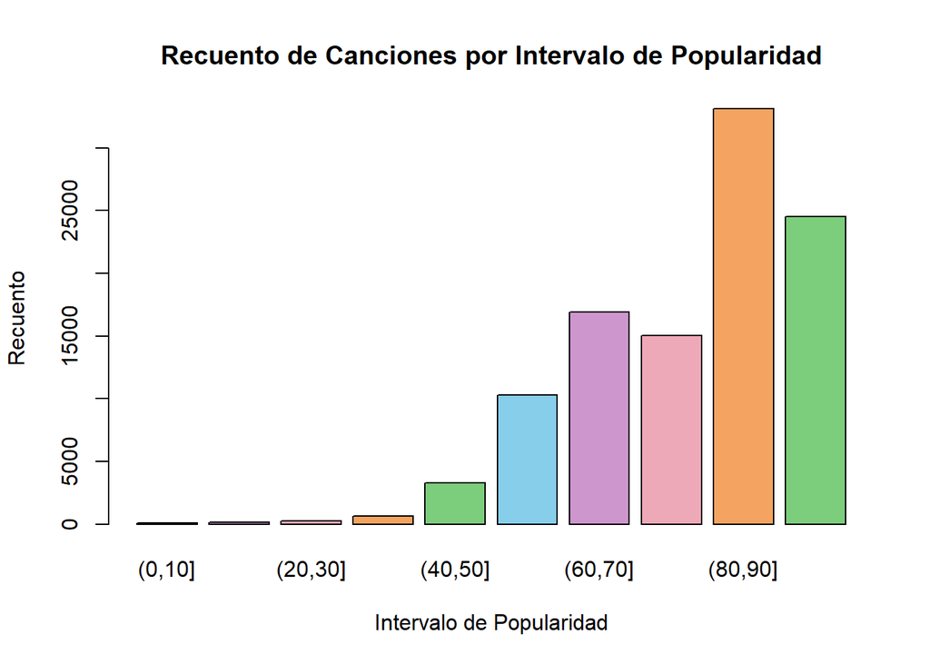

```r
spotify1 = spotify
#eliminamos columna paises
spotify1 = spotify1[,-c(1,8)]

# Calcula la media de la popularidad para cada canción
mean_popularity <- aggregate(popularity ~ name, data = spotify1, mean)

categories <- cut(spotify1$popularity, breaks = seq(0, 100, by = 10))
barplot(table(categories), main = "Recuento de Canciones por Intervalo de Popularidad", xlab = "Intervalo de Popularidad", ylab = "Recuento", col = colorspie)
```

Viendo este gráfico se nos ocurre para hacer nuestro pequeño análisis 3 grupos principales.

- **Muy poco populares**, cuyo rango será de 0 a 40, de las canciones existentes hay muy pocas canciones poco populares.
- **Populares**, cuyo rango de popularidad será de 40 a 80, este rango abarca canciones que han sido conocidas.
- **Muy populares**, cuyo rango de popularidad sera de 80 a 100, las canciones más populares y conocidas.

Después de haber hecho esta división vamos a seguir haciendo este análisis sin tener en cuenta los países, sino la popularidad “mundial” tras haber hecho la media para no ver en el análisis tantos valores donde la mayoría van a ser repetidos. Para ello ahora vamos a empezar visualizando las variables categóricas que pueden tener algo de relación con `popularity`.

Vamos a utilizar analysis_data, donde en principio no vamos a tener en cuenta el país:

```r
#primero convertimos las fechas
spotify1$snapshot_date = as.Date(spotify1$snapshot_date)
spotify1$album_release_date = as.Date(spotify1$album_release_date)

#creamos analysis_data donde hacemos media de todas las variables, ya que si estas tienen algun remix por ejemplo
#cambiaran su valencia, energia pero por muy pocas centesimas.
analysis_data <- aggregate(cbind(popularity, daily_rank, weekly_movement,daily_movement, danceability, energy, loudness, key, speechiness, acousticness, instrumentalness, liveness, valence, tempo, time_signature, duration_ms) ~ name + artists + album_name + is_explicit + album_release_date + mode, data = spotify1, mean)

#ponemos las fechas como minimo, ya que nos interesa cuando entraron a la lista por primera vez
analysis_data2 <- aggregate(cbind(snapshot_date) ~  name + artists + album_name + is_explicit + album_release_date + mode , data = spotify1, min)

analysis_data$snapshot_date = analysis_data2$snapshot_date

analysis_data$popularity_group <- cut(analysis_data$popularity, breaks = c(0, 40, 80, 100), labels = c("Poco Conocida", "Popular", "Muy Popular"),include.lowest = TRUE)
analysis_data$popularity_group <- factor(analysis_data$popularity_group, levels = c("Poco Conocida", "Popular", "Muy Popular"))
```

- Variable `key` Primero la pasamos a factor ya que actualmente se interpreta como numérica.

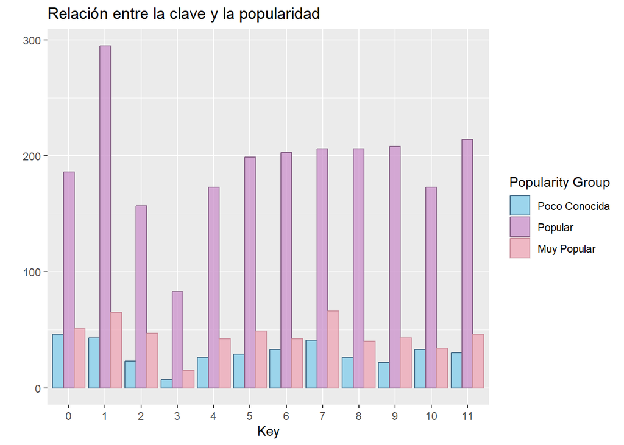

```r
analysis_data$key = factor(analysis_data$key)
myplot <- ggplot(data = analysis_data, aes(x = key, fill = popularity_group, color = popularity_group)) +
  geom_bar(alpha = 0.8, position = "dodge") +
  ggtitle("Relación entre la clave y la popularidad") +
  labs(x = "Key", y = "", fill = "Popularity Group") +
  scale_color_manual(values = colorpieborde, name = "Popularity Group") +
  scale_fill_manual(values = colorspie, name = "Popularity Group")
myplot
```

```r
table(analysis_data$popularity_group, analysis_data$key)
```

```
##
##                   0   1   2   3   4   5   6   7   8   9  10  11
##   Poco Conocida  46  43  23   7  26  29  33  41  26  22  33  30
##   Popular       186 295 157  83 173 199 203 206 206 208 173 214
##   Muy Popular    51  65  47  15  42  49  42  66  40  43  34  46
```

- `mode`

Analizando esta variable hemos descubierto que hay canciones que tienen un cambio de modo, es decir, que si una canción está en un principio en una tonalidad mayor otra variación de esta, un remix o incluso un error ocasiona que en algunas canciones haya cambios de modo. Entonces, si hacemos la media de esta variable agrupando las canciones por nombre y el resto de variables hay alguna cuyo modo varía, dando así valores intermedios, por lo que en el agrupamiento anteriormente hemos decidido que no se haga la media de esta variable.

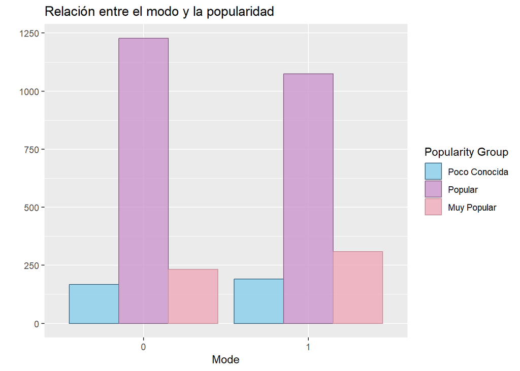

```r
analysis_data$mode = factor(analysis_data$mode)
myplot <- ggplot(data = analysis_data, aes(x = mode, fill = popularity_group, color = popularity_group)) +
  geom_bar(alpha = 0.8, position = "dodge") +
  ggtitle("Relación entre el modo y la popularidad") +
  labs(x = "Mode", y = "", fill = "Popularity Group") +
  scale_color_manual(values = colorpieborde, name = "Popularity Group") +
  scale_fill_manual(values = colorspie, name = "Popularity Group")
myplot
```

```r
table(analysis_data$popularity_group, analysis_data$mode)
```

```
##
##                    0    1
##   Poco Conocida  168  191
##   Popular       1228 1075
##   Muy Popular    232  308
```

- `is_explicit`

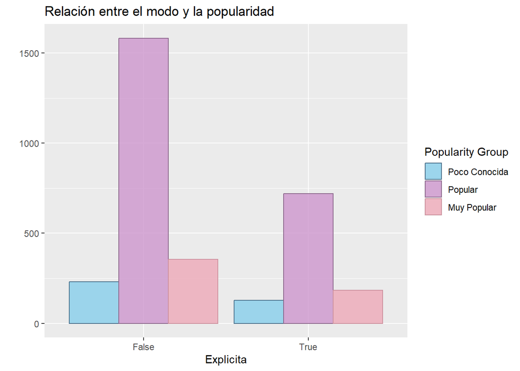

```r
analysis_data$is_explicit = factor(analysis_data$is_explicit)
myplot <- ggplot(data = analysis_data, aes(x = is_explicit, fill = popularity_group, color = popularity_group)) +
  geom_bar(alpha = 0.8, position = "dodge") +
  ggtitle("Relación entre el modo y la popularidad") +
  labs(x = "Explicita", y = "", fill = "Popularity Group") +
  scale_color_manual(values = colorpieborde, name = "Popularity Group") +
  scale_fill_manual(values = colorspie, name = "Popularity Group")
myplot
```

```r
table(analysis_data$popularity_group, analysis_data$is_explicit)
```

```
##
##                 False True
##   Poco Conocida   231  128
##   Popular        1583  720
##   Muy Popular     356  184
```

- `name`, `artists`, `album_name` Aunque estas variables no van a jugar un papel fundamental en nuestro modelo, es más, vamos a prescindir de ellas ya que lo que pretendemos es saber si una canción se hará o no famosa debido a sus atributos intrínsecos. Vamos a mostrar las canciones más populares, los artistas, y el nombre del album

```r
analysis_datasorted = analysis_data[order(-analysis_data$popularity),]

N<-10
artistastop = analysis_datasorted$artists[1:10]
cat("Artistas más populares\n")
```

```
## Artistas más populares
```

```r
artistastop
```

```
##  [1] "Taylor Swift"     "Tate McRae"       "Kenya Grace"      "iñigo quintero"
##  [5] "Jung Kook, Latto" "Myke Towers"      "Bad Bunny"        "Mitski"
##  [9] "V"                "Billie Eilish"
```

Estos son el top de artistas con más popularidad en este momento. Cada uno tiene diferentes canciones populares:

```r
popularity_counts <- table(analysis_datasorted$artists)

cat("Número de canciones en el dataset para cada artista:\n")
```

```
## Número de canciones en el dataset para cada artista:
```

```r
for (artist in artistastop) {
  cat(artist, ":", popularity_counts[artist], "canciones en la lista\n")
}
```

```
## Taylor Swift : 32 canciones en la lista
## Tate McRae : 1 canciones en la lista
## Kenya Grace : 1 canciones en la lista
## iñigo quintero : 1 canciones en la lista
## Jung Kook, Latto : 2 canciones en la lista
## Myke Towers : 1 canciones en la lista
## Bad Bunny : 14 canciones en la lista
## Mitski : 1 canciones en la lista
## V : 6 canciones en la lista
## Billie Eilish : 1 canciones en la lista
```

Y estas son las canciones y el nombre del álbum:

```r
canciones <- data.frame(
  Artista = analysis_datasorted$artists[1:10],
  Nombre = analysis_datasorted$name[1:10],
  Álbum = analysis_datasorted$album_name[1:10]
)
canciones
```

| Artista | Nombre | Álbum |
| --- | --- | --- |
| Taylor Swift | Cruel Summer | Lover |
| Tate McRae | greedy | greedy |
| Kenya Grace | Strangers | Strangers |
| iñigo quintero | Si No Estás | Si No Estás |
| Jung Kook, Latto | Seven (feat. Latto) (Explicit Ver.) | Seven (feat. Latto) |
| Myke Towers | LALA | LA VIDA ES UNA |
| Bad Bunny | MONACO | nadie sabe lo que va a pasar mañana |
| Mitski | My Love Mine All Mine | The Land Is Inhospitable and So Are We |
| V | Slow Dancing | Layover |
| Billie Eilish | What Was I Made For? [From The Motion Picture "Barbie"] | What Was I Made For? [From The Motion Picture "Barbie"] |

Esto no coincide con el ranking y somos conscientes de ello pero todavía no hemos analizado esas partes. Como recordatorio, esto solo lo hemos hecho para hablar un poco de los datos, estas tres variables no las vamos a tener muy en cuenta de ahora en adelante.

*Variables continuas*

- `daily_rank`

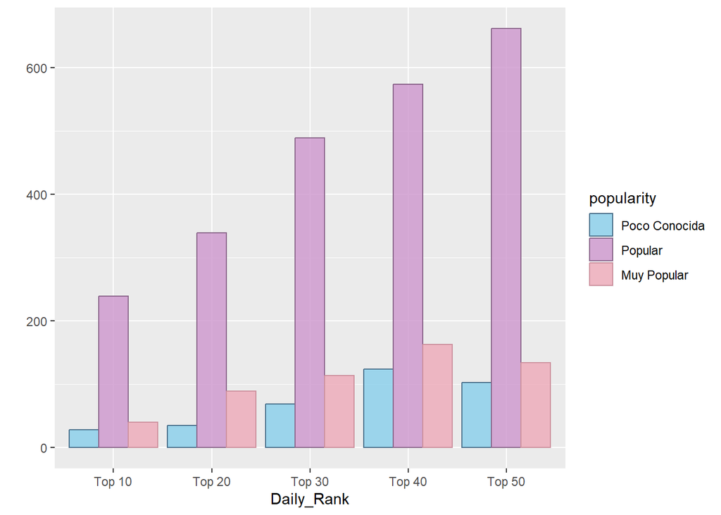

```r
analysis_data$daily_rank = round(analysis_data$daily_rank)

analysis_data$daily_rank_group <- cut(analysis_data$daily_rank, breaks = c(0, 10, 20, 30, 40, 50), labels = c("Top 10", "Top 20", "Top 30", "Top 40", "Top 50"),include.lowest = TRUE)

myplot = ggplot(data=analysis_data, aes(x=daily_rank_group, fill=popularity_group, color = popularity_group)) +
  geom_bar(alpha=0.8, position="dodge")+
  labs(x = "Daily_Rank",y="") +
  scale_color_manual(values = colorpieborde, name="popularity")+
  scale_fill_manual(values = colorspie, name="popularity")
myplot
```

Esto nos hace pensar que el ranking actual no significa que una canción sea muy popular. Estas van a ir ganando popularidad quizás con el tiempo que permanezca en la lista, pero las 10 primeras no se acercan en absoluto a las canciones más populares.

- `daily_movement`

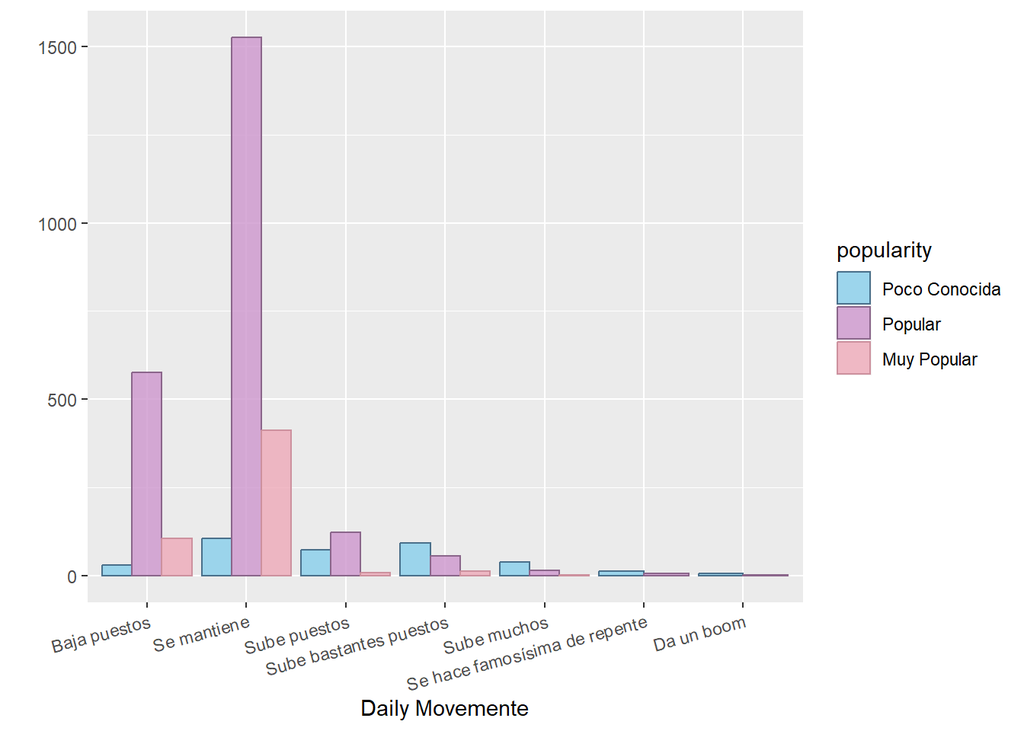

```r
analysis_data$daily_movement = round(analysis_data$daily_movement)

analysis_data$daily_movement_group <- cut(analysis_data$daily_movement, breaks = c(-10, 0, 5, 10, 20, 30, 40, 50), labels = c("Baja puestos", "Se mantiene", "Sube puestos", "Sube bastantes puestos", "Sube muchos", "Se hace famosísima de repente", "Da un boom"),include.lowest = TRUE)

myplot = ggplot(data=analysis_data, aes(x=daily_movement_group, fill=popularity_group, color = popularity_group)) +
  geom_bar(alpha=0.8, position="dodge")+
  labs(x = "Daily Movemente",y="") +
  scale_color_manual(values = colorpieborde, name="popularity")+
  scale_fill_manual(values = colorspie, name="popularity")+
  theme(axis.text.x = element_text(angle = 15, hjust = 1))
myplot
```

El movimiento diario nos muestra que las canciones que se mantienen son las más populares, esto es seguramente por aguantar más tiempo en un ranking superior.

- `weekly_movement`

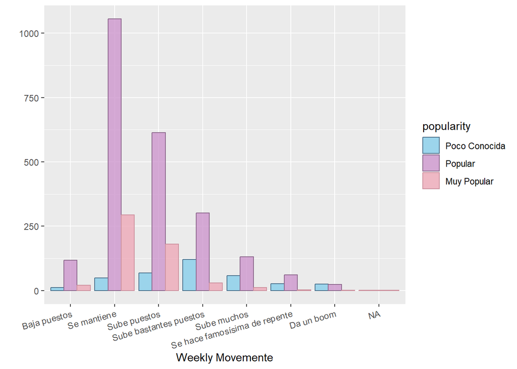

```r
analysis_data$weekly_movement = round(analysis_data$weekly_movement)

analysis_data$weekly_movement_group <- cut(analysis_data$weekly_movement, breaks = c(-20, 0, 5, 10, 20, 30, 40, 80), labels = c("Baja puestos", "Se mantiene", "Sube puestos", "Sube bastantes puestos", "Sube muchos", "Se hace famosísima de repente", "Da un boom"),include.lowest = TRUE)

myplot = ggplot(data=analysis_data, aes(x=weekly_movement_group, fill=popularity_group, color = popularity_group)) +
  geom_bar(alpha=0.8, position="dodge")+
  labs(x = "Weekly Movemente",y="") +
  scale_color_manual(values = colorpieborde, name="popularity")+
  scale_fill_manual(values = colorspie, name="popularity")+
  theme(axis.text.x = element_text(angle = 15, hjust = 1))
myplot
```

Aquí vemos que para algunas canciones hay NA’s pero este análisis no es con el conjunto de datos definitivo que vamos a tratar por lo que no las estamos teniendo en cuenta. Podemos ver como al igual que antes son las canciones que se mantienen las que más populares son.

- `snapshot_date` interesante análisis junto `album_realease_date`

Creemos que es interesante analizar el tiempo que tarda una canción en entrar en el dataset porque va a empezar a ganar popularidad para ello vamos a hacer una columna con el número de días que una canción tarda en hacerse famosa

```r
analysis_data$snapshot_date = as.Date(analysis_data$snapshot_date)
analysis_data$album_release_date = as.Date(analysis_data$album_release_date)

diferencia_dias = as.numeric(analysis_data$snapshot_date - analysis_data$album_release_date)
analysis_data$numDiasFama = diferencia_dias

analysis_data$numDiasFama = ifelse(analysis_data$numDiasFama <= 0, 0, analysis_data$numDiasFama)

analysis_data$numDiasFama_group <- cut(analysis_data$numDiasFama, breaks = c(-1, 1, 10, 30, 60, 90, 120, 99999), labels = c("Entra al salir", "10 dias", "1 mes", "2 meses", "3 meses", "4 meses", "+"),include.lowest = TRUE)
sum(is.na(analysis_data$numDiasFama))
```

```
## [1] 0
```

```r
sum(is.na(analysis_data$numDiasFama_group))
```

```
## [1] 0
```

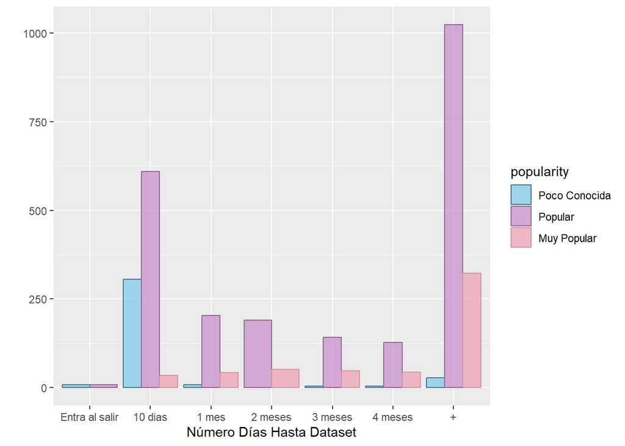

```r
myplot = ggplot(data=analysis_data, aes(x=numDiasFama_group, fill=popularity_group, color = popularity_group)) +
  geom_bar(alpha=0.8, position="dodge")+
  labs(x = "Número Días Hasta Dataset",y="") +
  scale_color_manual(values = colorpieborde, name="popularity")+
  scale_fill_manual(values = colorspie, name="popularity")
myplot
```

Son muy pocas las canciones que nada más salir entran al dataset de spotify. La mayoría de canciones que entran tienen mucha antigüedad siendo gran parte bastante populares. Además, cabe destacar que la popularidad de las que entran a los 10 dias de salir es baja.

- **CARACTERÍSTICAS DE LAS CANCIONES** `duration_ms`, `danceability`, `energy`, `loudness`, `speechiness`, `accousticness`, `liveness`, `instrumentalness`, `valence`, `tempo`, `time_signature`

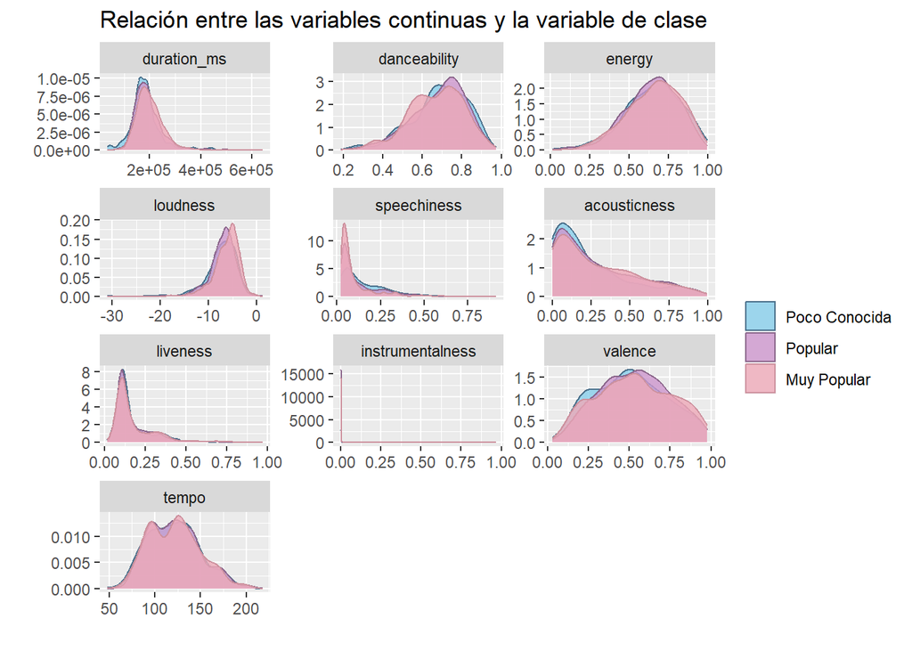

```r
analysisContinuas= analysis_data[ , c("popularity_group", "duration_ms", "danceability","energy", "loudness", "speechiness", "acousticness", "liveness", "instrumentalness", "valence", "tempo")]
mymelt=melt(analysisContinuas, id.vars=1, value.name="FeatureValue", variable.name="Feature")

myplot = ggplot(data=mymelt, aes(x=FeatureValue, fill=popularity_group, color = popularity_group)) +
  geom_density(alpha=0.8)+
  ggtitle("Relación entre las variables continuas y la variable de clase")+
  labs(x = "",y="", fill = "") +
  scale_color_manual(values = colorpieborde, name="")+
  scale_fill_manual(values = colorspie, name="")+
  facet_wrap(~ Feature, ncol=3, scales = "free")
myplot
```

Creemos que además de con la popularidad, estas variables van a estar bastante correlacionadas entre sí.

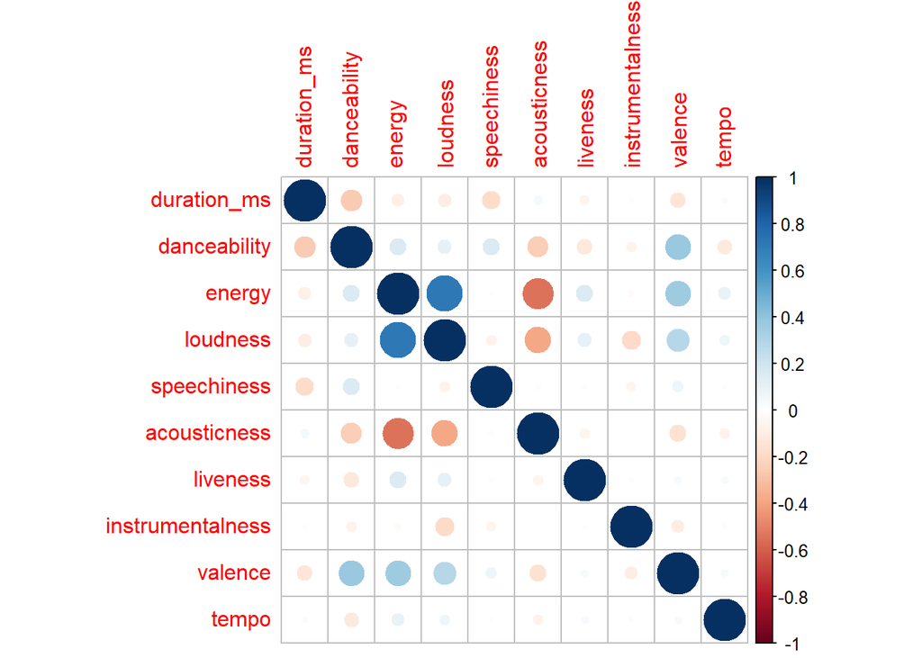

```r
analysisContinuas= analysis_data[ , c("duration_ms", "danceability","energy", "loudness", "speechiness", "acousticness", "liveness", "instrumentalness", "valence", "tempo")]
corrplot::corrplot(cor(analysisContinuas))
```

- Por último, `time_signature`

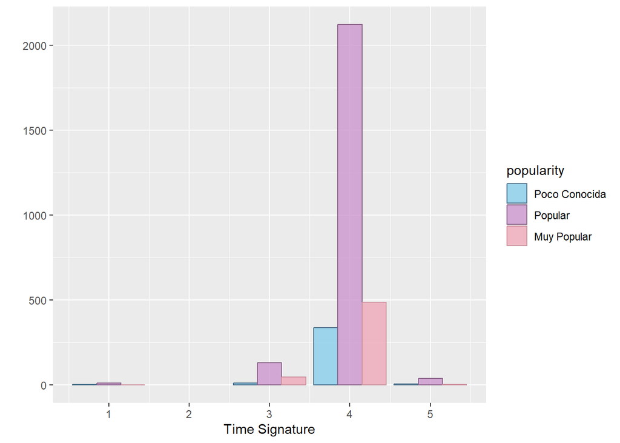

```r
myplot = ggplot(data=analysis_data, aes(x=time_signature, fill=popularity_group, color = popularity_group)) +
  geom_bar(alpha=0.8, position="dodge")+
  labs(x = "Time Signature",y="") +
  scale_color_manual(values = colorpieborde, name="popularity")+
  scale_fill_manual(values = colorspie, name="popularity")
myplot
```

Vemos como casi todas las canciones tienen un `time_signature` de 4, y que no hay ninguna con 2. Por lo tanto seguramente esta variable sea un poco indiferente a la hora de conocer la popularidad. Pero nos ayudará a determinar que la mayoría de canciones se hacen populares cuando su `time_signature` es de 4.

*TODO* Antes de comenzar con las preguntas del apartado 1, nos gustaría hacer un pequeño PCA para mostrar si con las variables que tenemos numéricas seríamos capaces de determinar algo de información sobre la popularidad.

```r
analysis_pca = analysisContinuas
analysis_pca$daily_rank = analysis_data$daily_rank
analysis_pca$weekly_movement = analysis_data$weekly_movement
analysis_pca$daily_movement = analysis_data$daily_movement
analysis_pca$time_signature = analysis_data$time_signature
analysis_pca$numDiasFama = analysis_data$numDiasFama
analysis_pca_estatus = analysis_data$popularity_group

# PCA
pca_result <- prcomp(analysis_pca, scale = TRUE)
row.names(pca_result$x) = analysis_pca_estatus
pcas = as.data.frame(pca_result$x, stringsAsFactors =F)
pcas = cbind(ESTATUS = analysis_pca_estatus,pcas)
```

[figure not shown]

```r
ggplot(pcas, aes(PC1, PC2, color = ESTATUS, shape=ESTATUS)) +
  geom_point(size = 1, alpha=0.6) +
  geom_hline(yintercept = 0, linetype = "dashed") +
  geom_vline(xintercept = 0, linetype = "dashed") +
  scale_color_manual(values = colorspie) +
  scale_shape_manual(values = c(17, 16, 15)) +
  xlab("Primera componente principal") +
  ylab("Segunda componente principal") +
  ggtitle("Las dos primeras componentes principales de titanicData") +
  guides(color = guide_legend(title = "Estado de Popularidad"), shape = guide_legend(title = "Estado de Popularidad")) +
  theme_minimal() +
  theme(legend.position = "top")
```

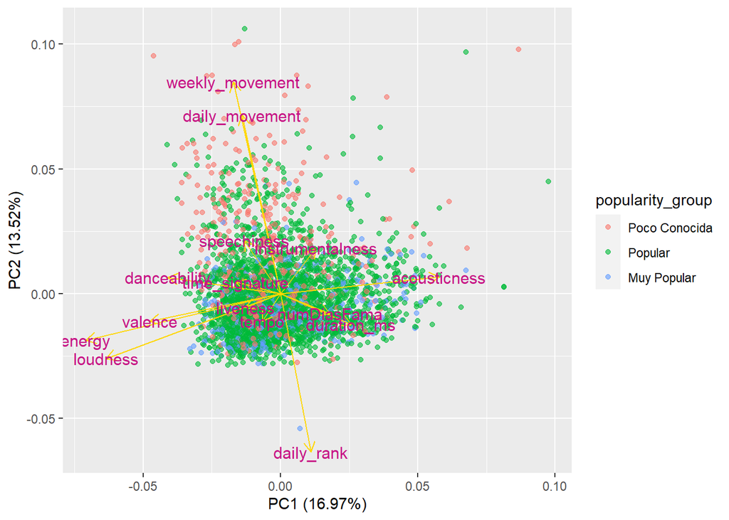

```r
autoplot(pca_result, data=analysis_data, cex = 0.7, alpha=0.6, color = "popularity_group",
         loadings = TRUE, loadings.colour = 'gold',
         loadings.label = TRUE, loadings.label.size = 4, loadings.label.colour = 'mediumvioletred')
```

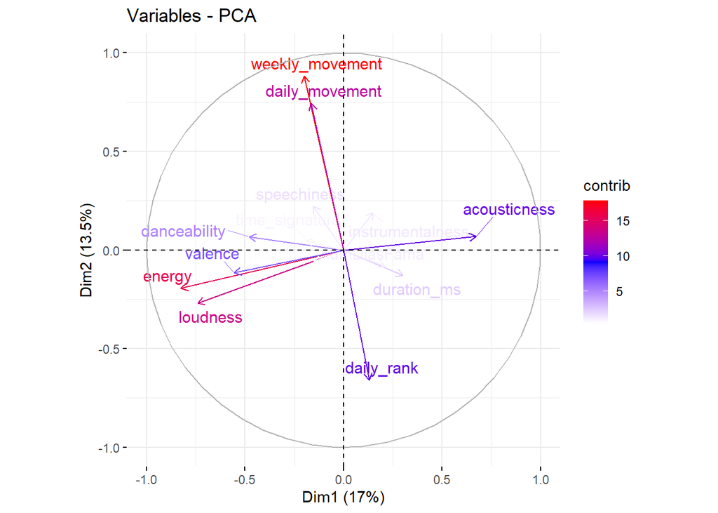

```r
fviz_pca_var(pca_result, col.var = "contrib",
             gradient.cols = c("white", "blue", "red"),
             repel = TRUE)
```

Debido a la gran cantidad de datos es casi imposible ver lo que nos muestra este PCA, aunque podemos ver la parte representativa de cada componente en el análisis. También se nos dice que variables como weekly_movement, energy, loudness… Presentan una gran variación para nuestros datos.

```r
(VE <- pca_result$sdev^2)
```

```
##  [1] 2.5457552 2.0277093 1.4487292 1.1404952 1.0548321 1.0242345 1.0121277
##  [8] 0.9503283 0.8379470 0.7629439 0.6634979 0.6526931 0.4195450 0.2391605
## [15] 0.2200011
```

```r
PVE <- VE / sum(VE)
cumsum(round(PVE, 2))
```

```
##  [1] 0.17 0.31 0.41 0.49 0.56 0.63 0.70 0.76 0.82 0.87 0.91 0.95 0.98 1.00 1.01
```

Finalmente vamos a analizar un poco de la variable `country` la que hemos eliminado anteriormente sin tener reparo en que esta variable tendrá canciones con popularidad distinta en cada país, vamos a quedarnos con aquellas con mayor popularidad y por lo tanto vamos a ver solo un poco de como afectan las variables numéricas a los distintos países. *TODO*

```r
library(rnaturalearth)
library(ggplot2)
library(purrr)
library(cowplot)

analysis_data <- aggregate(cbind(popularity, daily_rank, weekly_movement,daily_movement, danceability, energy, loudness, key, speechiness, acousticness, instrumentalness, liveness, valence, tempo, time_signature, duration_ms) ~ name + artists + album_name + is_explicit + album_release_date + mode + country, data = spotify, mean)

analysis_data2 <- aggregate(cbind(snapshot_date) ~  name + artists + album_name + is_explicit + album_release_date + mode + country , data = spotify, min)

analysis_data$snapshot_date = analysis_data2$snapshot_date

# Cargar datos de límites de países
world <- ne_countries(returnclass = "sf")

world = world[, c("iso_a2", "geometry")]

# Crear un conjunto de datos de ejemplo
spotify_mean <- data.frame(
  country= analysis_data$country,
  popularity = analysis_data$popularity,
  is_explicit = analysis_data$is_explicit,
  duration_ms = analysis_data$duration_ms,
  danceability = analysis_data$danceability,
  energy = analysis_data$energy,
  loudness = analysis_data$loudness,
  speechiness = analysis_data$speechiness,
  liveness = analysis_data$liveness,
  instrumentalness = analysis_data$instrumentalness,
  valence = analysis_data$valence,
  tempo = analysis_data$tempo
)

# Quedarse con las filas en las que la popularidad es mayor que 80
spotify_mean <- spotify_mean[spotify_mean$popularity > 80, ]

# Unir datos de Spotify con datos del mundo
world_spotify <- merge(world, spotify_mean, by.x = "iso_a2", by.y = "country", all.x = FALSE)

# Lista de variables a usar en cada mapa
variables <- c("duration_ms", "danceability", "energy", "loudness", "speechiness", "liveness", "valence", "tempo")

# Crear una lista de gráficos usando purrr::map
maps <- map(variables, function(var) {
  ggplot() +
    geom_sf(data = world_spotify, aes_string(fill = var)) +
    scale_fill_gradient(low = "lightyellow", high = "sandybrown") +
    theme_minimal() +
    labs(title = var)  # Título con el nombre de la variable
})

plot_grid(plotlist = maps, ncol = 3)
```

[output not shown]

```r
rm(analysis_data, analysis_data2, analysis_datasorted,mean_popularity, canciones, mymelt, artist, pcas, pca_result, spotify_mean, spotify1, world, world_spotify, myplot, maps, analysisContinuas, analysis_pca, analysis_pca_estatus, artistastop, categories, diferencia_dias, N, popularity_counts, PVE, variables, VE)
```

Después de haber hecho este pequeño análisis, cuyos datos son una muestra representativa del conjunto inicial pasamos a responder las preguntas del apartado A.

**Describe además, los atributos predictores del conjunto y la variable a predecir. Divide la descripción de los atributos en cuatro grupos, a saber. Justifica el porqué entiendes que cada atributo tiene o no relación con `popularity`.**

**1. predictores numéricos que, a priori, no tienen relación alguna con `popularity` y por tanto no son útiles para su predicción.**

Vamos a nombrar cada variable que pensamos que no tienen relación con su correspondiente justificación.

- `album_release_date`: no estamos muy seguras de si esta variable se tratará más adelante o si tendrá relación con la popularidad.
- `snapshot_date`: La fecha en la que se recogieron los datos podría ser importante porque la popularidad de una canción puede variar con el tiempo aunque no estamos muy seguro de ellos.

**2. Predictores numéricos que pueden aportar algo a la predicción de `popularity` y predictores categóricos.**

Como hemos hecho en el apartado anterior, vamos ir explicanco junto a la variable que creemos que sí puede aportar el porqué de esta creencia.

Para los predictores numéricos:

- `daily_rank`: La posición diaria en el ranking puede ser un indicador importante de la popularidad de una canción. Si una canción ocupa constantemente un lugar alto es probable que sea popular.
- `daily_movement`: El cambio diario de la posición podría indicar tendencias en la popularidad de la canción, en caso de subir seguramente indique un aumento de popularidad.
- `weekly_movement`: Es parecido al anterior, pero a más largo plazo.
- `valence`: La media de positivismo transmitido por la canción podría influir en su atractivo general, las cancioens más alegres o las más triste suelen ser las más populares pero si no trasmites nada seguramente no sea popular.
- `tempo`: El número de beats por minuto puede influir en la percepción de energía de una canción y ser más popular.
- `energy`: La energía de la canción podría ser un factor calve en su atractivo puesto que las canciones más enérgicas podrían tener mayor probabilidad de ser populares.
- `time_signature`: Creemos que el nivel en una esacala de ritmo musical tiene relación con las dos anteriores por lo que pensamos que puede ser relevante para la popularidad de una canción.
- `speechiness`: La presencia de palabra hablada en una canción es muy importante pues la gran mayoría de canciones (por no decir todas) que están en los rankings de popularidad suelen ser todas con letra.
- `instrumentalness`: La predominandia de la instrumentación sobre la voz pordría influir de la misma forma que la anterior.
- `duration_ms`: como hemos visto antes esta variable podria estar relacionada con la popularidad
- `liveness`: el porcentaje de una canción que se grabó en vivo o en estudio influirá en la popularidad.
- `acousticness`: la calidad acústica de la música es algo que tambien tendra relación.
- `loudness`: pensamos que el nivel de decibelios al que fue grabada la canción importará para la popularidad.
- `danceability`: La capacidad de una canción para ser baildad podría ser una factor importante.

Y para los predictores categóricos:

- `mode`: Si la canción está en modo mayor o menos podría influir en la percepción emocional y, por tanto, en su popularidad.
- `is_explicit`: La presencia de lenguaje explícito podría atraet a ciertos públicos y afectar. Por ejemplo, muchas canciones muy populares latinoamericanas tienen un alto porcentaje de palabras sexuales y escenarios explícitos y, a veces, cuan más explícito es más repercusión tiene. Por otra parte, canciones con un lenguaje explícito de violencia no suelen ser populares por motivos obvios.
- `key`: pensamos que la escala en la que está compuesta podrá afectar a la popularidad.

**3. Relacionados con `popularity`.**

Pensamos que las variables que más relación tienen con la popularidad son los puestos que tiene una canción diariamente y semanal y sus movimientos entre los puestos. `daily_rank`, `daily_movement` y `weekly_movement`.

**4. No relacionados.**

- `artists`: El artista podría ser un factor importante pues artitas más reconocidos tienen más propabilidad de producir canciones populares. Pero, no nos servira en nuestro estudio ya que estamos planteando hacer un reconocimiento para canciones nuevas que no tienen por que ser de artistas conocidos, por eso no nos va a aportar nada en el modelo que vamos a entrenar.
- `spotify_id`: no tiene relación porque es simplemente una forma de identificar la canción.
- `name`: creemos que el nombre de la canción no tendrá relevancia porque muchas de las canciones que más escuchamos en nuestro día a día porque se han hecho ``virales’’ gracias a las redes sociales no conocemos sus nombres en un principio.
- `country`: la ubicación geográfica del origen de la canción no tiene una correlación evidente con su popularidad ya que la mayoría de canciones que escuchamos que son populares no sabemos cuál es su origen o no nos interesa para porder disfrutarla.
- `album_name`: muchas de las canciones no más populares no salen ni en un álbum y en general, la gente no se fija en el álbum en sí al que pertenece una canción, simplemente en la canción si les gusta.

# 2 Apartado B

## 2.1 Preparación de datos

Para empezar vamos a **eliminar la variable X**, ya que creemos que es una variable nula que se ha colado en la lectura del csv, después vamos a pasar a variables categóricas key y mode ya que actualmente se consideran como numéricas. Y convertiremos las clases `album_release_date` y `snapshot_date` en fechas, en lugar de cadenas para despues poder tratar con ellas.

```r
spotify = spotify[,-1]

spotify$mode = factor(spotify$mode)
spotify$key = factor(spotify$key)

spotify$album_release_date = as.Date(spotify$album_release_date)
spotify$snapshot_date = as.Date(spotify$snapshot_date)
```

A continuación vamos a mirar los **NA’s** que presentan nuestras variables.

```r
colSums(is.na(spotify))
```

```
##         spotify_id               name            artists         daily_rank
##                  0                 21                 21                  0
##     daily_movement    weekly_movement            country      snapshot_date
##                  0                  0               1452                  0
##         popularity        is_explicit        duration_ms         album_name
##                  0                  0                  0                 22
## album_release_date       danceability             energy                key
##                 22                  0                  0                  0
##           loudness               mode        speechiness       acousticness
##                  0                  0                  0                  0
##   instrumentalness           liveness            valence              tempo
##                  0                  0                  0                  0
##     time_signature
##                  0
```

Después de haber mirado un poco por encima el dataset, sabemos que los 21 valores nulos que se muestran con `name` y `artists` son los mismos, al igual que los 22 de `album_release_date` y `album_name`. Además 21 de ellos coinciden como nulos con `name` y `album_name`.

Aquí podemos ver la cantidad de nulos que coinciden con `name` y `artists`

```r
table(is.na(spotify$name), is.na(spotify$artists))
```

```
##
##          FALSE   TRUE
##   FALSE 105648      0
##   TRUE       0     21
```

Aquí vemos la cantidad de nulos que coinciden con `album_release_date` y `album_name`

```r
table(is.na(spotify$album_release_date), is.na(spotify$album_name))
```

```
##
##          FALSE   TRUE
##   FALSE 105647      0
##   TRUE       0     22
```

y aquí la cantidad de nulos que coinciden con `name`y `album_release_date`

```r
table(is.na(spotify$name), is.na(spotify$album_name))
```

```
##
##          FALSE   TRUE
##   FALSE 105647      1
##   TRUE       0     21
```

Lo que vamos a hacer es eliminar los 22 valores nulos de estas distintas filas, ya que consideramos que son pocos los datos de los que vamos a prescindir.

```r
spotify <- spotify[complete.cases(spotify$album_release_date), ]

colSums(is.na(spotify))
```

```
##         spotify_id               name            artists         daily_rank
##                  0                  0                  0                  0
##     daily_movement    weekly_movement            country      snapshot_date
##                  0                  0               1452                  0
##         popularity        is_explicit        duration_ms         album_name
##                  0                  0                  0                  0
## album_release_date       danceability             energy                key
##                  0                  0                  0                  0
##           loudness               mode        speechiness       acousticness
##                  0                  0                  0                  0
##   instrumentalness           liveness            valence              tempo
##                  0                  0                  0                  0
##     time_signature
##                  0
```

Ahora podemos ver que solo quedan 1452 nulos en la columna `country` del dataset. La estrategia que vamos a utilizar es omitir estas filas también, ya que contando actualmente con 105647 datos, creemos que podemos prescindir de estos 1452 nulos, dejándonos así con 104195 valores para nuestro trabajo de investigación.

```r
table(is.na(spotify$country))
```

```
##
##  FALSE   TRUE
## 104195   1452
```

```r
spotify <- spotify[complete.cases(spotify$country), ]
```

A continuación, vamos a ver si tenemos **outliers** y en caso de verlos, los eliminaremos ya que queremos trabajar con los datos más representativos y cercanos entre sí, dejando así un mejor dataset para la predicción.

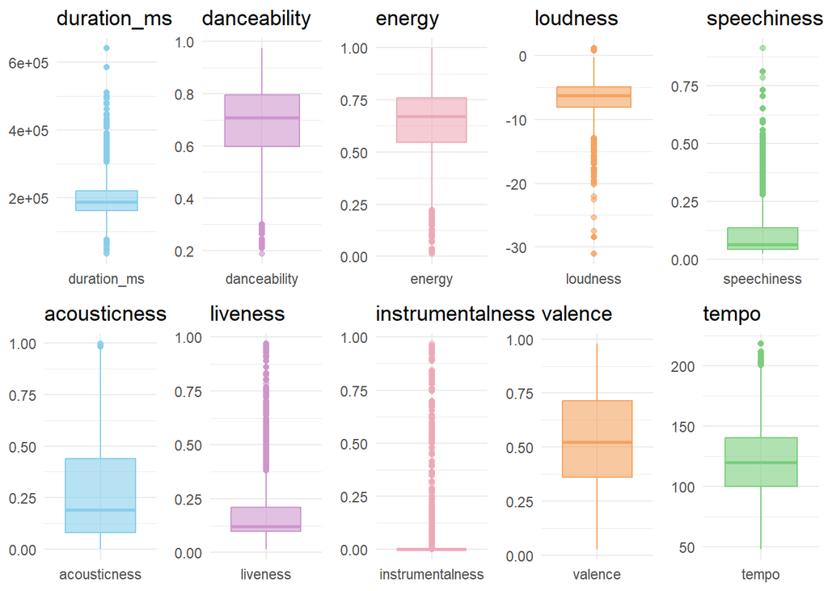

```r
analysisContinuas= spotify[ , c("popularity", "duration_ms", "danceability","energy", "loudness", "speechiness", "acousticness", "liveness", "instrumentalness", "valence", "tempo")]
mymelt=melt(analysisContinuas, id.vars=1, value.name="FeatureValue", variable.name="Feature")


unique_features <- unique(mymelt$Feature)
num_columns <- 5
num_rows <- ceiling(length(unique_features) / num_columns)
plots_list <- list()

# Tamaño total de la cuadrícula
total_width <- 15
total_height <- 20
single_plot_width <- total_width / num_columns
single_plot_height <- total_height / num_rows

# Itera a través de cada característica
for (i in seq_along(unique_features)) {
  subset_data <- mymelt[mymelt$Feature == unique_features[i], ]
   current_color <- colorspie[(i - 1) %% length(colorspie) + 1]

  # Crea el gráfico con ggplot usando los datos filtrados
  plot <- ggplot(data=subset_data, aes(x=Feature, y=FeatureValue, color=Feature, fill=Feature)) +
    geom_boxplot(alpha=0.6) +
    scale_fill_manual(values = current_color) +
    scale_color_manual(values = current_color) +
    ggtitle(paste(unique_features[i])) +
    theme_minimal() +
    theme(legend.position="none",
          axis.title.x = element_blank(),  # Oculta la etiqueta del eje x
          axis.title.y = element_blank())

  # Agrega el gráfico a la lista
  plots_list[[i]] <- plot

  summary(mymelt)
}

# Organiza los gráficos en una cuadrícula y visualízalos
grid.arrange(grobs = plots_list, ncol = num_columns, widths = rep(single_plot_width, num_columns), heights = rep(single_plot_height, num_rows))
```

Un dato será *outlier* si se encuentra más allá de 3/2 del rango de intercuartil

```r
analysisContinuas= spotify[ , c( "duration_ms", "danceability","energy", "loudness", "speechiness", "acousticness", "liveness", "instrumentalness", "valence", "tempo")]

iqr_values <- apply(analysisContinuas, 2, function(x) {
  q1 <- quantile(x, 0.25)
  q3 <- quantile(x, 0.75)
  iqr <- q3 - q1
  limite_inferior <- q1 - 1.5 * iqr
  limite_superior <- q3 + 1.5 * iqr

  outliers_count <- sum(x < limite_inferior | x > limite_superior)

  return(list(Q1 = q1, Q3 = q3, IQR = iqr, LimiteInferior = limite_inferior, LimiteSuperior = limite_superior, Outliers = outliers_count))
})

for (i in seq_along(iqr_values)) {
  cat("Variable:", names(iqr_values)[i], "\n")
  cat("  Primer cuartil (Q1):", iqr_values[[i]]$Q1, "\n")
  cat("  Tercer cuartil (Q3):", iqr_values[[i]]$Q3, "\n")
  cat("  IQR:", iqr_values[[i]]$IQR, "\n")
  cat("  Límite inferior:", iqr_values[[i]]$LimiteInferior, "\n")
  cat("  Límite superior:", iqr_values[[i]]$LimiteSuperior, "\n")
  cat("  Número de outliers", iqr_values[[i]]$Outliers, "\n")
  cat("\n\n")
}
```

```
## Variable: duration_ms
##   Primer cuartil (Q1): 162767
##   Tercer cuartil (Q3): 220116
##   IQR: 57349
##   Límite inferior: 76743.5
##   Límite superior: 306139.5
##   Número de outliers 2758
##
##
## Variable: danceability
##   Primer cuartil (Q1): 0.598
##   Tercer cuartil (Q3): 0.796
##   IQR: 0.198
##   Límite inferior: 0.301
##   Límite superior: 1.093
##   Número de outliers 372
##
##
## Variable: energy
##   Primer cuartil (Q1): 0.546
##   Tercer cuartil (Q3): 0.759
##   IQR: 0.213
##   Límite inferior: 0.2265
##   Límite superior: 1.0785
##   Número de outliers 1531
##
##
## Variable: loudness
##   Primer cuartil (Q1): -8.051
##   Tercer cuartil (Q3): -4.849
##   IQR: 3.202
##   Límite inferior: -12.854
##   Límite superior: -0.046
##   Número de outliers 3182
##
##
## Variable: speechiness
##   Primer cuartil (Q1): 0.0408
##   Tercer cuartil (Q3): 0.136
##   IQR: 0.0952
```

[output cut: 33 more lines]

```
##   Primer cuartil (Q1): 0.361
##   Tercer cuartil (Q3): 0.715
##   IQR: 0.354
##   Límite inferior: -0.17
##   Límite superior: 1.246
##   Número de outliers 0
##
##
## Variable: tempo
##   Primer cuartil (Q1): 99.971
##   Tercer cuartil (Q3): 140.02
##   IQR: 40.049
##   Límite inferior: 39.8975
##   Límite superior: 200.0935
##   Número de outliers 374
```

A pesar de ver una gran cantidad de datos outliers al hacer el cálculo teórico, creemos que no son datos que haya que borrar porque hay muchos juntos como ocurre en la gráfica con `instrumentalness`, que por la representación se ve que no hay ningún punto de datos que destaque por estar muy lejano al resto.

Por otra parte, apoyándonos en los datos visuales de la gráfica y en los que acabamos de obtener, vamos a eliminar algunos valores de: `duration_ms`, `loudness` y `speechiness`.

```r
spotifyEliminacion <- spotify
# Marcamos los datos que eliminaremos de duration_ms
spotifyEliminacion$duration_delete <- if_else(spotifyEliminacion$duration_ms > 570000, TRUE, FALSE)
sum(spotifyEliminacion$duration_ms > 570000)
```

```
## [1] 63
```

```r
# Marcamos los datos de loudness
spotifyEliminacion$loudness_delete <- if_else(spotifyEliminacion$loudness > 0 | spotifyEliminacion$loudness< -25, TRUE, FALSE)
sum(spotifyEliminacion$loudness< -25 | spotifyEliminacion$loudness > 0)
```

```
## [1] 58
```

```r
# Marcamos los datos de speechiness
spotifyEliminacion$speechiness_delete <- if_else(spotifyEliminacion$speechiness > 0.7, TRUE, FALSE)
sum(spotifyEliminacion$speechiness > 0.7)
```

```
## [1] 57
```

```r
# Eliminamos estas filas
spotifyEliminacion <- spotifyEliminacion %>%
  filter(!(duration_delete | loudness_delete | speechiness_delete))
spotify <- spotifyEliminacion[, 1:25]

rm(spotifyEliminacion); rm(subset_data);
```

Otra idea que se nos ocurre es tener en cuenta los días que hay desde que se publica una canción hasta que esta obtiene una nueva posición en el ranking, la forma en la que podemos hacer esto es restar `snapshot_date` con `album_release_date` y tener así un registro del número de **días que una canción tardó en hacerse popular**, como la fecha de salida de una canción puede ser anterior a la salida de un álbum pondremos como 0 aquellas canciones que tienen como diferencia de fechas un valor negativo.

```r
diferencia_dias = as.numeric(spotify$snapshot_date - spotify$album_release_date)

spotify$diferencia_dias = diferencia_dias
spotify$diferencia_dias = ifelse(spotify$diferencia_dias < 0, 0, spotify$diferencia_dias)
```

Ahora vamos a calcular la **popularidad previa** de canciones en un conjunto de datos.

```r
spotify <- spotify %>%
  group_by(spotify_id,country) %>%
  arrange(snapshot_date) %>%
  mutate(prev_popularity=if_else(as.numeric(difftime(as.Date(snapshot_date),
                              lag(as.Date(snapshot_date)), units = "days")) >= 1 &
                              as.numeric(difftime(as.Date(snapshot_date), lag(as.Date(snapshot_date)),
                              units = "days")) <= 7, lag(popularity), 0))
```

Primero organizamos la información por identificador y país, asegurándose de que los registros estén ordenados; luego, para cada canción se determina la popularidad que tenía en fechas anteriores, considerando únicamente aquellas con una diferencia de 1 a 7 días respecto a la fecha actual. El resultado es una nueva columna llamada `prev_popularity`, que refleja la popularidad previa de cada canción en el tiempo.

Hasta ahora no hemos hecho nada más que añadir columnas, pero sabemos de antemano que no todas ellas nos van a ser de utilidad para entrenar nuestro modelo. Sin embargo, no las hemos eliminado anteriormente para hacer la limpieza de datos pero ahora procedemos a quitar las columnas `spotify_id`, `name`, `artists`, `album_name`, `album_release_date`

```r
spotify = spotify[, -c(1,2,3,12,13)]
```

Anteriormente hemos agrupado los argumentos `album_release_date` y `snapshot_date` en la variable que recoge la diferencia de días. Por lo que ahora también consideramos oportuno quitar la variable `snapshot_date` ya que ya tenemos en el dataset el número de días que la canción ha tardado en tener la respectiva `popularity`.

```r
spotify = spotify[, -5]
```

```r
spotify = spotify[, -c(4,21)]
```

**Respóndase a las siguientes preguntas en relación a la preparación de datos.**

* **¿Qué predictores habría que normalizar? ¿Por qué? ¿Cuál sería la estrategia de normalización en cada caso?**

Los predictores que habría que normalizar son `duration_ms`, `loudness`, `tempo`, `diferencia_dias`.

- `duration_ms`: pensamos que una mejor forma de analizar la duración de las canciones es si normalizamos estos valores con segundos en vez de milisegundos pues así no tenemos datos muy específico que, además, no creemos que una diferencia de milisegundos entre las canciones afecte a los resultados y de esta forma es más fácil comparar las duraciones pues en spotify el valor mínimo que se guarda de cara al público es en segundos.

```r
spotiNormalizado = spotify
spotiNormalizado$duration_sec <- trunc(spotiNormalizado$duration_ms / 1000)
spotiNormalizado <- subset(spotiNormalizado, select = -c(duration_ms))
```

```r
max <- max(spotiNormalizado$loudness)
min <- min(spotiNormalizado$loudness)
spotiNormalizado$loudness <- (spotiNormalizado$loudness-min)/(max-min)
```

```r
max <- max(spotiNormalizado$tempo)
min <- min(spotiNormalizado$tempo)
spotiNormalizado$tempo <- (spotiNormalizado$tempo-min)/(max-min)
```

* **¿Podría ser interesante transformar algún atributo o grupos de atributos en uno nuevo? ¿Por qué?**

Sí, lo hemos hecho anteriormente combinando las variables `album_release_date` y `snapshot_date` dando lugar a `diferencia_dias`. También podríamos considerar la creación de una nueva varibale que represente la rapidez con la que una canción se vuelve popular. Por ejemplo, podríamos crear una variable `velocidad_popularidad` que sea el inverso de la diferencia de días, de manera que canciones que se vuelven populares rápidamente tengan valores más altos en esta nueva variable.

```r
spotiNormalizado$velocidad_popularidad <- 1/spotify$diferencia_dias
```

* **¿Cómo podría aprovecharse el carácter secuencial de los datos?**

El carácter secuancial de los datos podría aprovechase al considerar la creación de variables que capturen tendencias a lo largo del tiempo. Por ejemplo, un poco más arriba hemos creado una variable `prev_popularity` gracias a que las fechas son secuenciales y podemos acceder a la popularidad a lo largo de los días. De esta forma podemos analizar cómo cambia la popularidad de una canción a lo largo de la semana anterior, proporcionando información valiosa para entender patrones y tendencias en el comportamiento de reproducción de las canciones en la plataforma.

# 3 Apartado C

## 3.1 Random Forest

### 3.1.1 Funcionamiento

**Explicar brevemente el tipo de modelo que genera el algoritmo, y cuál es la estrategia de dicho algoritmos para construir el modelo.**

El algoritmo **Random Forest** se utiliza para tareas de clasificaión y de regresión. Su estructura consiste en un conjunto de árboles de decisión, de ahí que se denomine ``bosque’’. La estrategia principal del Random Forest se basa en la combinación de múltiples árboles de decisión mediante el siguiente proceso:

1. **Muestreo aleatorio de datos:** Se toma el conjunto de entrenamiento y se crean múltiples subconjuntos mediante muestreo aleatorio con reemplazo.
2. **Construcción de árbolres de decisión:** Cada subconjunto se utiliza para entrenar un árbol de decisión mediante un proceso recursivo de partición basado en la mejor característica.
3. **Valoración:** Se realiza la predicción para cada árbol y, en clasificación, se realiza una votación para determinar la clase final y en regresión, se promedian las predicciones.

La idea clave es combinar la información de múltiples árboles para reducir sobreajuste y mejorar la generalización.

### 3.1.2 Requisitos

**Indicar si el algoritmo en cuestión tiene algún requisito en cuanto a si se han de preprocesar los datos (e.g. escalado, imputación de valores nulos, etc.) y cómo. Explicar cómo se ha tenido en cuenta estos requisitos a la hora de generar los datos de training específicos para este algoritmo.**

Random Forest no tiene requisitos estrictos en cuanto al preprocesamiento de datos. Sin embargo, cambios que hemos hecho en los datos ayudarán al rendimiento como puede ser la normalización de los valores, la eliminación de datos no relevantes y el manejo de los valores nulos.

## 3.2 Deep learning

### 3.2.1 Funcionamiento

**Explicar brevemente el tipo de modelo que genera el algoritmo, y cuál es la estrategia de dicho algoritmos para construir el modelo.**

El **Deep Learning** se utiliza en redes neuronales profundas para modelar y resolver problemas complejos. Una red neuronal profunda consta de múltiples capas, incluyendo capas de entrada, capas ocultas y capas de salida por las que van pasando los datos. La estrategia es la siguiente:

1. **Propagación hacia adelante (Forward Propagation):** Los datos se introducen en la red y se propagan hacia adelante a través de las capas, generando una predicción.
2. **Cálculo de pérdida:** Se compara la predicción con las etiquetas reales para calcular la pérdida.
3. **Retropropagación (Backward Propagation):** Se propaga hacia atrás la pérdida a través de la red, ajustando los pesos de las conexiones para minimizar la pérdida.
4. **Optimización:** Se utiliza un algoritmo de optimización *(como Gradiente Descendente)* para actualizar los pesos y minimizar la pérdida.

Este proceso se repite en varias épocas (iteraciones a través del conjunto de datos) durante el entrenamiento.

### 3.2.2 Requisitos

**Indicar si el algoritmo en cuestión tiene algún requisito en cuanto a si se han de preprocesar los datos (e.g. escalado, imputación de valores nulos, etc.) y cómo. Explicar cómo se ha tenido en cuenta estos requisitos a la hora de generar los datos de training específicos para este algoritmo.**

Los requisitos para el Deep Learning incluyen:

- Normalización de variables: para que tengan una media cercana a cero y una desviación estándar similar.
- Manejo de valores nulos: los datos deben estar limpios de valores nulos antes del entrenamiento.
- Codificación de variables categóricas: las variables categóricas deben codificarse adecuadamente para ser utilizadas en la red neuronal.

## 3.3 Cluestering

### 3.3.1 Funcionamiento

**Explicar brevemente el tipo de modelo que genera el algoritmo, y cuál es la estrategia de dicho algoritmos para construir el modelo.**

El algoritmo de clustering se utiliza para agrupar datos similares entre sí en conjuntos llamados “clusters”. Uno de los métodos más comunes es el k-means. Su estrategia es la siguiente:

1. **Inicialización:** Se seleccionan aleatoriamente los centroides iniciales para los k clusters.
2. **Asignación:** Cada punto de datos se asigna al cluster cuyo centroide es el más cercano.
3. **Actualización:** Se recalculan los centroides de los clusters basándose en los puntos de datos asignados.
4. **Iteración:** Se repiten los pasos 2 y 3 hasta que los centroides convergen o se alcanza un número máximo de iteraciones.

El resultado es un conjunto de clusters donde los puntos de datos dentro de cada cluster son más similares entre sí que con aquellos en otros clusters.

### 3.3.2 Requisitos

**Indicar si el algoritmo en cuestión tiene algún requisito en cuanto a si se han de preprocesar los datos (e.g. escalado, imputación de valores nulos, etc.) y cómo. Explicar cómo se ha tenido en cuenta estos requisitos a la hora de generar los datos de training específicos para este algoritmo.**

Los requisitos para el clustering, especialmente para k-means, incluyen:

- Escalado de variables: Dado que el algoritmo de k-means se basa en distancias euclidianas, es importante escalar las variables para que tengan la misma influencia en el cálculo de las distancias. Esto ya lo hemos contemplado en la preparación de los datos.
- Manejo de valores nulos: Los valores nulos pueden afectar la calidad del clustering, por lo que es importante tratarlos antes del entrenamiento, lo cual hemos ya.

# 4 Apartado D